# 正态分布与三大分布

2023-10-12

# **视频资源**

- [如何用Excel创建标准正态分布函数表？](https://www.bilibili.com/video/BV1Uv4y1p71t/)
- [Excel 中dist inv函数的运用](https://www.bilibili.com/video/BV19Z4y1G7qF/)
- [EXCEL 利用Norm.dist函数绘制正态分布概率密度曲线](https://www.bilibili.com/video/BV1Hi4y1L7Eg/)
- [EXCEL 利用t.dist函数绘制T分布概率密度曲线](https://www.bilibili.com/video/BV1df4y1i7c9/)
- [EXCEL 利用chisq.dist函数绘制卡方分布概率密度曲线](https://www.bilibili.com/video/BV1F54y1k7sc/)
- [EXCEL 利用F.dist函数绘制F分布概率密度曲线？](https://www.bilibili.com/video/BV1KV41117mR/)

# **习题**

1.在同⼀个坐标系下绘制N(0,1),N(-1,0.25),N(2,4)的概率密度曲线。

2.在同⼀个坐标系下绘制N(0,1), t(2), t(5),t(30)的概率密度曲线。

3.在同⼀个坐标系下绘制chisq(5), chisq(10), chisq(30)的概率密度曲线。

4.同⼀个坐标系下绘制F(2, 5), F(5, 10)的概率密度曲线。

5.生成服从自由度5的卡方分布的500个随机数，绘制其直方图。

6.生成服从自由度5的t分布的500个随机数，绘制其直方图。

7.生成服从自由度30的卡方分布的500个随机数，绘制其直方图。

8.生成服从F(5,30)的500个随机数，绘制其直方图。

9.利用Excel的函数完成下列计算。

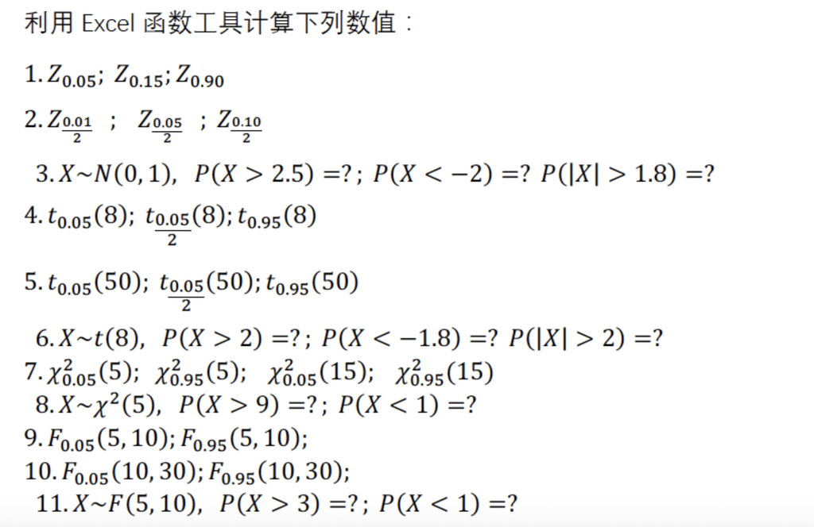

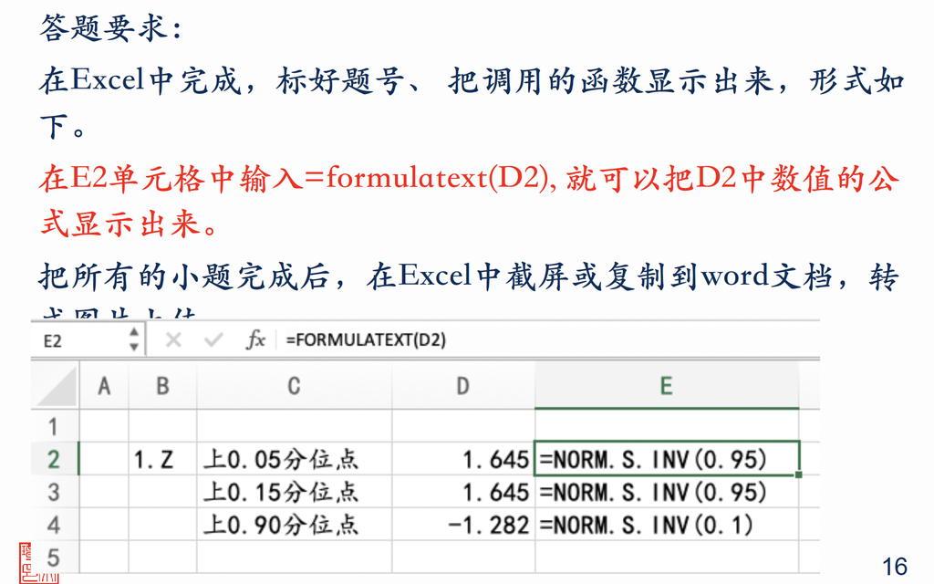